# Assignment 2 Maps

Mary Geschwindt

9/18/2020

## Assignment Setup

First I will load my libraries.

```r
library(tidyverse)
library(ggplot2)
library(sf)
library(rnaturalearth)
library(rnaturalearthdata)
library(ggspatial)
library(cartogram)
library(ggthemes)
```

## Maps

### World Map

I’ll start with a world map:

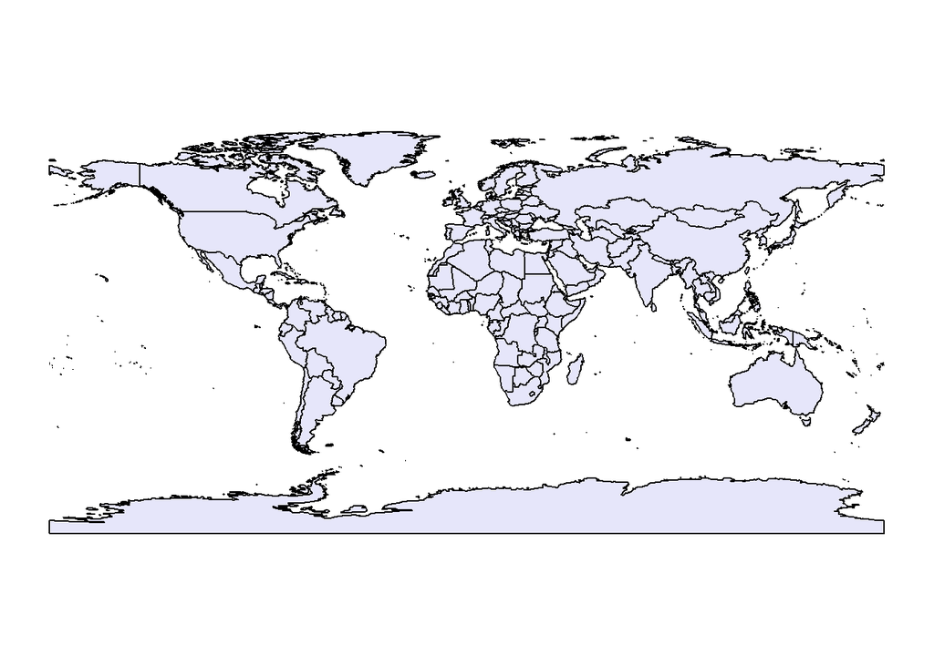

```r
world <- ne_countries(scale = 50, returnclass = "sf")

world_map <- ggplot(world) +
  geom_sf(color = "black", fill = "lavender") +
  theme_map()

world_map
```

### European Countries Map

I want to look at countries in Europe as my subareas for this assignment, so I will create an initial map without defining any projections or coordinate systems to see what this looks like.

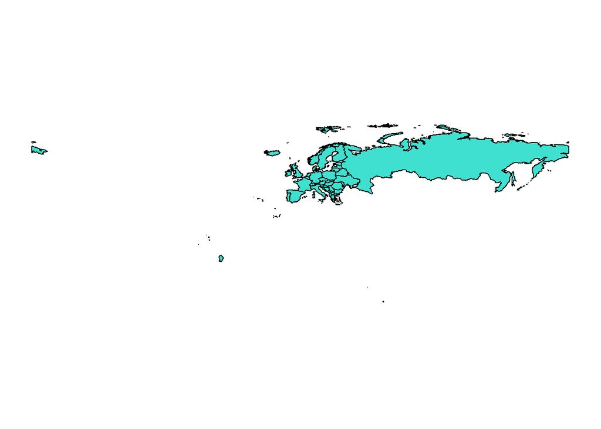

```r
eu_countries <- world %>%
  filter(continent == "Europe")

eu_map <- ggplot(eu_countries) +
  geom_sf(color = "black", fill = "turquoise") +
  theme_map()

eu_map
```

## Map Projections

Now that I know how to create a map, I will officially begin the assignment. I’ll be using countries in Europe as my selected subareas.

I will define three projections I’m using here, which I got from spatialreference.org. In order, the projections are a Lambert Azimuthal Equal-Area Projection, a Transverse Mercator Projection, and a longitude/latitude coordinate reference system.

```r
eu_coord1 <- "+proj=laea +lat_0=55 +lon_0=20 +x_0=0 +y_0=0 +a=6370997 +b=6370997 +units=m +no_defs"
eu_coord2 <- "+proj=tmerc +lat_0=0 +lon_0=0 +k=0.9996 +x_0=500000 +y_0=0 +ellps=intl +units=m +no_defs"
eu_coord3 <- "+proj=longlat +ellps=GRS80 +towgs84=0.0,0.0,0.0,0.0,0.0,0.0,0.0 +no_defs"
```

### Map Projection 1

I’ll transform the European countries map using the first projection, which is a Lambert Azimuthal Equal-Area projection from spatialreference.org/ref/esri/9059 :

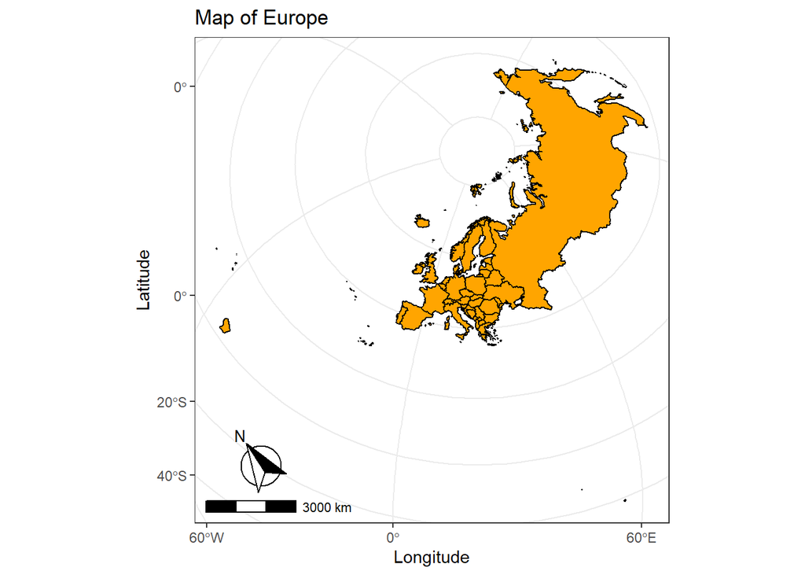

```r
ggplot(eu_countries) +
  geom_sf(color = "black", fill = "orange") +
  coord_sf(crs = eu_coord1) +
  xlab("Longitude") + ylab("Latitude") +
  ggtitle("Map of Europe") +
  annotation_scale(location = "bl") +
  annotation_north_arrow(location = "bl", which_north = "true", pad_x = unit(0.25, "in"), pad_y = unit(0.25, "in"), style = north_arrow_fancy_orienteering) +
  theme_bw()
```

### Map Projection 2

I’ll transform the European countries map using the second projection, which is a Transverse Mercator projection from spatialreference.org/ref/epsg/23090 :

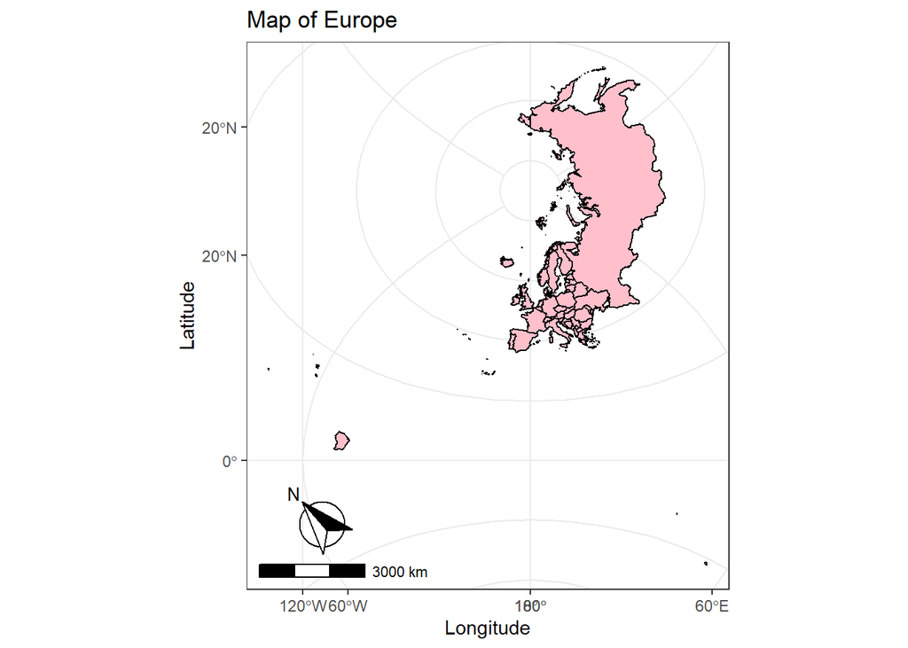

```r
ggplot(eu_countries) +
  geom_sf(color = "black", fill = "pink") +
  coord_sf(crs = eu_coord2) +
  xlab("Longitude") + ylab("Latitude") +
  ggtitle("Map of Europe") +
  annotation_scale(location = "bl") +
  annotation_north_arrow(location = "bl", which_north = "true", pad_x = unit(0.25, "in"), pad_y = unit(0.25, "in"), style = north_arrow_fancy_orienteering) +
  theme_bw()
```

### Map Projection 3

I’ll transform the European countries map using the third projection, which uses a latitude/longitude coordinate reference system from spatialreference.org/ref/epsg/62586413 :

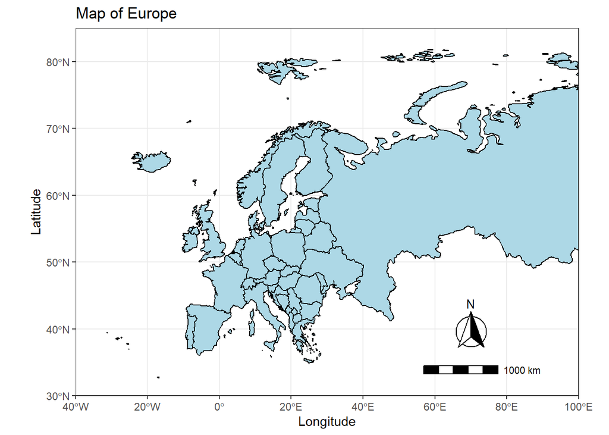

```r
ggplot(eu_countries) +
  geom_sf(color = "black", fill = "lightblue") +
  coord_sf(crs = eu_coord3, xlim = c(-40, 100), ylim = c(30, 85), expand = FALSE) +
  xlab("Longitude") + ylab("Latitude") +
  ggtitle("Map of Europe") +
  annotation_scale(location = "bl", pad_x = unit(4, "in"), pad_y = unit(0.25, "in")) +
  annotation_north_arrow(location = "bl", which_north = "true", pad_x = unit(4.25, "in"), pad_y = unit(0.5, "in"), style = north_arrow_fancy_orienteering) +
  theme_bw()
```

## Variables & Figures

I will now select a variable to study how it varies among the countries of Europe. I have chosen to look at each country’s population.

### Transformed Projection

For some of the following figures, I know that I want to use a projection which allows me to reference areas. I’ll use the Lambert Azimuthal Equal-Area projection from my first map, which I had labeled “eu_coord1”.

```r
eu_transformed <- eu_countries %>%
  st_transform(crs = eu_coord1)
```

### Figure 1 - Chloropleth Map

For my first figure, I’ll create a chloropleth map. I’ll be using the third projection I created for this assignment.

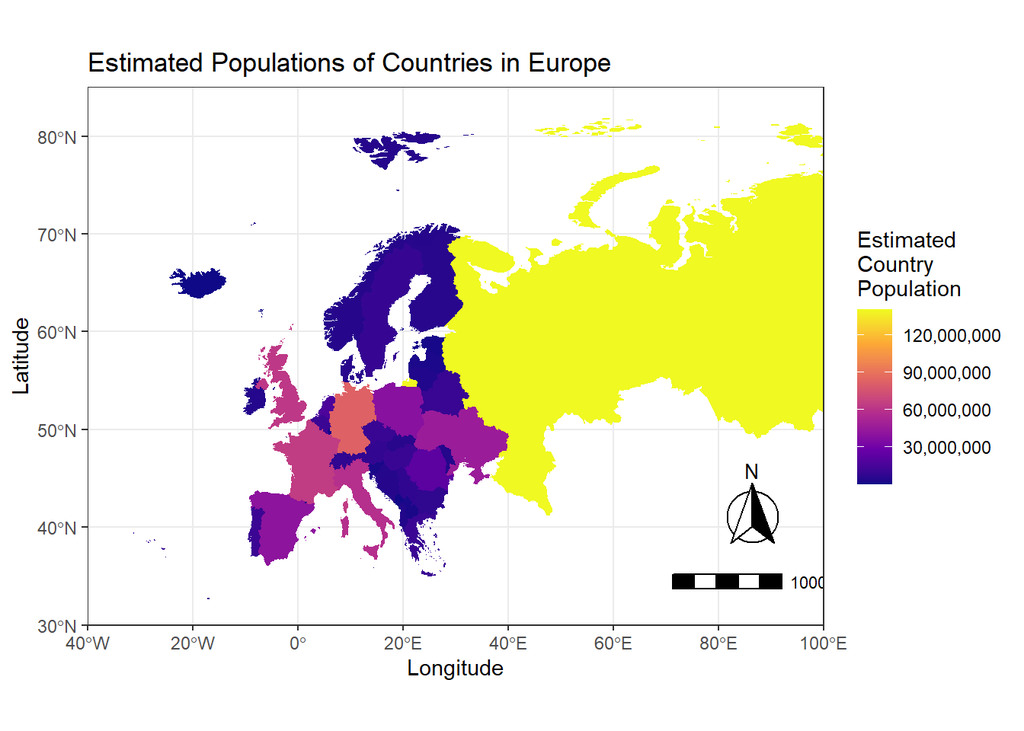

```r
eu_pop <- eu_countries %>%
  select(name, pop_est)

ggplot(eu_pop, aes(fill = pop_est)) +
  geom_sf(color = NA) +
  coord_sf(crs = eu_coord3, xlim = c(-40, 100), ylim = c(30, 85), expand = FALSE) +
  scale_fill_viridis_c(option = "plasma",
                       name = "Estimated\nCountry\nPopulation",
                       breaks = seq(0, 150000000, by = 30000000),
                       labels = formatC(seq(0, 150000000, by = 30000000),
                                        big.mark = ",", format = "f", digits = 0)) +
  xlab("Longitude") + ylab("Latitude") +
  ggtitle("Estimated Populations of Countries in Europe") +
  annotation_scale(location = "bl", pad_x = unit(4, "in"), pad_y = unit(0.25, "in")) +
  annotation_north_arrow(location = "bl", which_north = "true", pad_x = unit(4.25, "in"), pad_y = unit(0.5, "in"), style = north_arrow_fancy_orienteering) +
  theme_bw() +
  theme(legend.background = element_blank())
```

### Figure 2 - Non-Continuous Cartogram

For my second figure, I’ll create a non-continuous cartogram. I’ll use the transformed projection I created earlier for this figure.

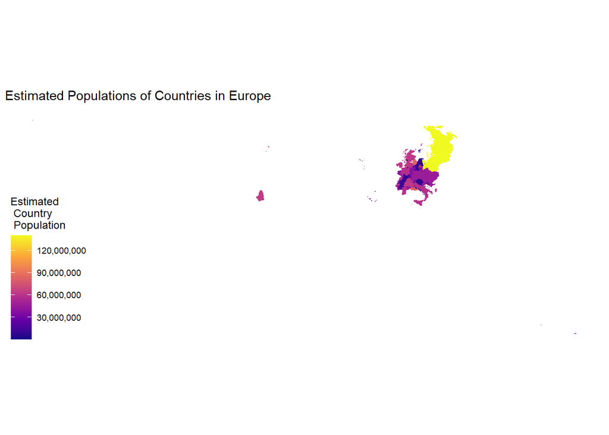

```r
eu_cartogram <- eu_transformed %>%
  cartogram_ncont("pop_est")

ggplot(eu_cartogram, aes(fill = pop_est)) +
  geom_sf(color = NA) +
  ggtitle("Estimated Populations of Countries in Europe") +
  scale_fill_viridis_c(option = "plasma",
                       name = "Estimated\n Country\n Population",
                       breaks = seq(0, 150000000, by = 30000000),
                       labels = formatC(seq(0, 150000000, by = 30000000),
                                        big.mark = ",", format = "f", digits = 0)) +
  theme_map() +
  theme(legend.background = element_blank())
```

### FIgure 3 - Dorling Cartogram

For my final figure, I’ll create a dorling cartogram. I’ll use the transformed projection I created earlier for this figure.

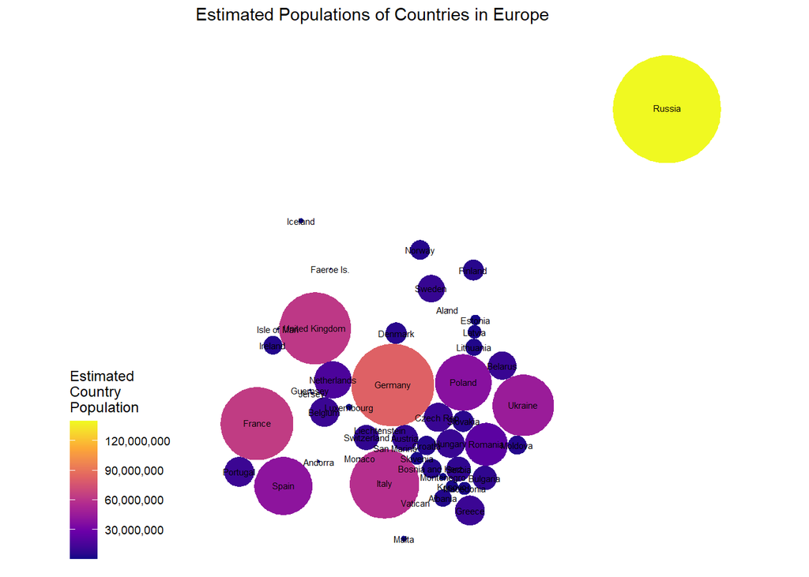

```r
eu_cartogram_dorling <- eu_transformed %>%
  cartogram_dorling("pop_est")

ggplot(eu_cartogram_dorling, aes(fill = pop_est)) +
  geom_sf(color = NA) +
  scale_fill_viridis_c(option = "plasma",
                       name = "Estimated\nCountry\nPopulation",
                       breaks = seq(0, 150000000, by = 30000000),
                       labels = formatC(seq(0, 150000000, by = 30000000),
                                        big.mark = ",", format = "f", digits = 0)) +
  ggtitle("Estimated Populations of Countries in Europe") +
  geom_sf_text(aes(label = name),
                #color = "white",
                size = 2) +
  theme_map() +
  theme(legend.background = element_blank()) +
  theme(legend.position = "left")
```

In another iteration of this dorling cartogram, I would adjust the labels of the country names to be as legible as possible. I think that labels are important in such a map because the location of European countries relative to one another in such an abstract representation may not be as obvious to an audience, depending on who that audience is.

## Assignment 2 Conclusion

I am now familiar with creating maps, assigning labels and colors, applying appropriate scales, and most importantly, controlling projections. I can see now how the control over map projections, because there are so many types of distortions which can be produced, can change the way the map and the information presented are perceived.

As for creating various figures based on these maps, I can start to see how such figures can be a more abstract means of representing location based data. After completing this exercise, I understand the principle that maps are merely a representation of reality and cannot accurately reflect the true geography of the earth, and that creating such abstract figures is just another means of representing geospatial data. One still needs to be careful of what message the distortions send to the audience, and whether or not the distortions produce something which is accurate, honest, and useful.